# Homework 10

Lindsey Carlson

3/30/2022

## For Loops and Randomization Tests

*Worked on some parts of the code with Stephen Peters Collaer*

### Question 1 - Using a for loop, write a function to calculate the number of zeroes in a numeric vector. Before entering the loop, set up a counter variable counter <- 0. Inside the loop, add 1 to counter each time you have a zero in the matrix. Finally, use return(counter) for the output.

```r
##################################################
# FUNCTION: num_zero
# purpose: count number of zeros
# input: x vectors of numeric
# output: count of number of zeros
#-------------------------------------------------
num_zeros <- function(vector1 = sample(0:3, size = 1000, replace = TRUE)){
  counter <- 0
  for(i in 1:length(vector1)){
    if(vector1[i]== 0){
      counter <- counter + 1
    }
  }
  return(counter)
}

num_zeros()
```

```
## [1] 262
```

### Question 2 - Use subsetting instead of a loop to rewrite the function as a single line of code.

```r
##################################################
# FUNCTION: num_zero_sub
# purpose: count number of zeros
# input: x vectors of numeric
# output: count of number of zeros
#-------------------------------------------------
num_zeros_sub <- function(vector1 = sample(0:3, size = 1000, replace = TRUE)){
 length(vector1[vector1 == 0])
}

num_zeros_sub()
```

```
## [1] 257
```

### Question 3 - Write a function that takes as input two integers representing the number of rows and columns in a matrix. The output is a matrix of these dimensions in which each element is the product of the row number x the column number.

```r
##################################################
# FUNCTION: mat_product
# purpose: multiply the row number x by column number
# input: number of rows and columns in a matrix
# output: product of the row number and column number
#-------------------------------------------------

mat_product <- function(nrow=4, ncol=4){
  mat <- matrix(nrow=4, ncol=4)
  for(i in 1:nrow){
    for(j in 1:ncol){
      mat[i,j] <- i*j
    }
  }
  print(mat)
}

mat_product()
```

```
##      [,1] [,2] [,3] [,4]
## [1,]    1    2    3    4
## [2,]    2    4    6    8
## [3,]    3    6    9   12
## [4,]    4    8   12   16
```

### Question 4 - In the next few lectures, you will learn how to do a randomization test on your data. We will complete some of the steps today to practice calling custom functions within a for loop. Use the code from the March 31st lecture (Randomization Tests) to complete the following steps:

*a. Simulate a dataset with 3 groups of data, each group drawn from a distribution with a different mean. The final data frame should have 1 column for group and 1 column for the response variable.*

```r
group <- c(rep("A", 100), rep("B", 100), rep("C", 100))
A <- rnorm(n=100, mean = 1, sd = 0.1)
B <- rnorm(n=100, mean = 2, sd = 0.1)
C <- rnorm(n=100, mean = 3, sd = 0.1)

response <- c(A, B, C)
d_frame <- data.frame(group, response)

print(d_frame)
```

```
##     group  response
## 1       A 1.0019609
## 2       A 1.0078340
## 3       A 0.9299108
## 4       A 0.9615667
## 5       A 1.1729902
## 6       A 0.9763787
## 7       A 1.1238164
## 8       A 1.1358989
## 9       A 1.0871031
## 10      A 0.7685526
## 11      A 1.1116612
## 12      A 0.9205906
## 13      A 0.9025214
## 14      A 0.8737203
```

[output cut: 286 more lines]

*b. Write a custom function that 1) reshuffles the response variable, and 2) calculates the mean of each group in the reshuffled data. Store the means in a vector of length 3.*

```r
library(dplyr)
##################################################
# FUNCTION: reshuffle
# purpose: get means of reshuffled data
# input: groups of data (A, B, C)
# output: vector length of 3 with means of each group
#-------------------------------------------------
reshuffle <- function(df = d_frame, response = response){
  colnames(d_frame) <- c('group', 'response')
  new_shuff <- sample(1:nrow(d_frame), replace=FALSE)
    d_frame <- data.frame(group, new_shuff)
  sum_mean <- d_frame %>% group_by(group) %>% summarise(mean = mean(new_shuff))
      return(sum_mean)
}

reshuffle()
```

```
## # A tibble: 3 x 2
##   group  mean
##   <chr> <dbl>
## 1 A      149.
## 2 B      153.
## 3 C      149.
```

*c. Use a for loop to repeat the function in b 100 times. Store the results in a data frame that has 1 column indicating the replicate number and 1 column for each new group mean, for a total of 4 columns.*

```r
library(tidyr)

results <- data.frame()

for(i in 1:100){
  shuff <- sample(1:nrow(d_frame), replace=FALSE)
    d_frame_shuff <- data.frame(group, shuff)
  sum_mean <- d_frame_shuff %>% group_by(group) %>%
    summarise(mean = mean(shuff))
  df <- sum_mean %>% pivot_wider(names_from = group, values_from = mean)
  final_df <- cbind(i, df)

  results <- rbind(results, final_df)
}

print(results)
```

```
##       i      A      B      C
## 1     1 164.33 134.96 152.21
## 2     2 136.91 154.88 159.71
## 3     3 152.42 148.80 150.28
## 4     4 142.73 155.93 152.84
## 5     5 148.92 154.44 148.14
## 6     6 153.28 159.64 138.58
## 7     7 161.98 148.57 140.95
## 8     8 140.91 160.28 150.31
## 9     9 142.58 141.90 167.02
## 10   10 156.84 158.09 136.57
## 11   11 148.00 153.10 150.40
## 12   12 155.27 153.61 142.62
## 13   13 160.27 142.79 148.44
## 14   14 147.35 149.32 154.83
```

[output cut: 86 more lines]

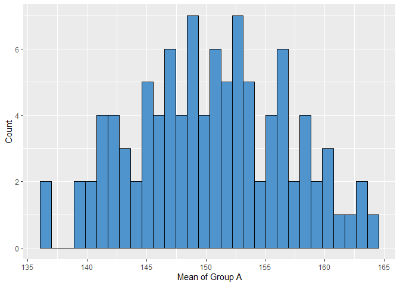

```r
library(ggplot2)

mean_plotA <- qplot(x=A, data = results,
                   geom = "histogram",
                   xlab = "Mean of Group A",
                   ylab = "Count",
                   color=I("black"),
                   fill=I("Steelblue3"))

  print(mean_plotA)
```

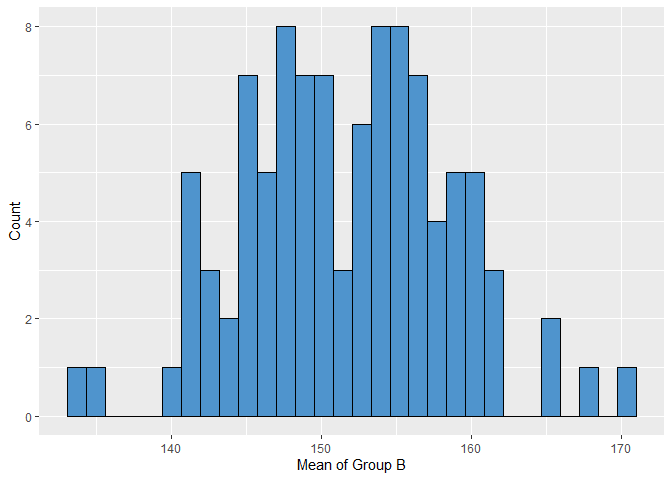

```r
mean_plotB <- qplot(x=B, data = results,
                   geom = "histogram",
                   xlab = "Mean of Group B",
                   ylab = "Count",
                   color=I("black"),
                   fill=I("Steelblue3"))

  print(mean_plotB)
```

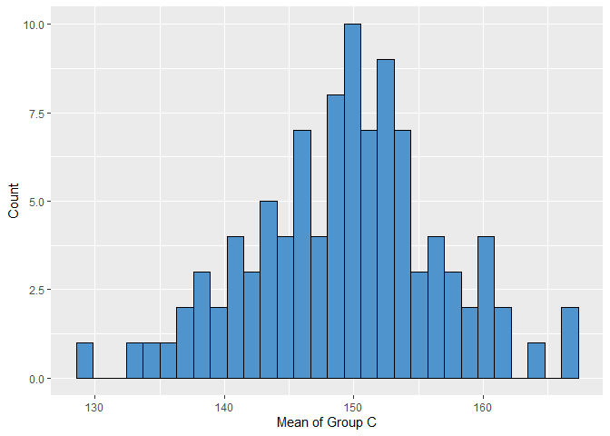

```r
mean_plotC <- qplot(x=C, data = results,
                   geom = "histogram",
                   xlab = "Mean of Group C",
                   ylab = "Count",
                   color=I("black"),
                   fill=I("Steelblue3"))

  print(mean_plotC)
```